# TwitteR and tidytext Packages

5/3/2018

First, install and set the library for the following packages:

```r
install.packages("twitteR")
library(twitteR)
```

Now we can set up authentification for the Twitter API

```r
setup_twitter_oauth(getOption("twitter_consumer_key"),
                    getOption("twitter_consumer_secret"),
                    getOption("twitter_access_token"),
                    getOption("twitter_access_token_secret"))
```

Obtaining your access token and consumer key:

1. Create a Twitter account
2. Create a Twitter app at https://apps.twitter.com/

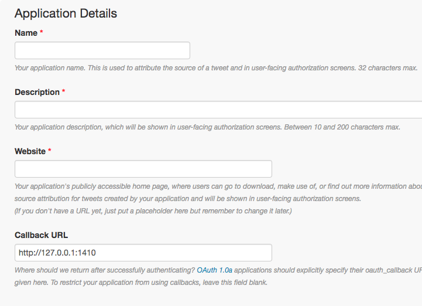

3. Generate Access Token

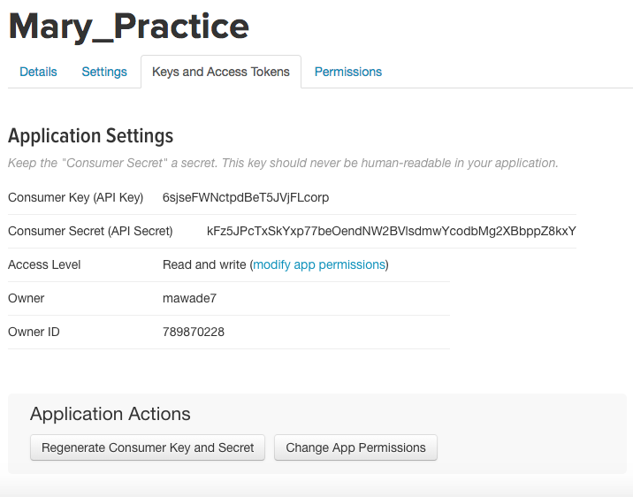

If you need additional help, there is more information here: https://cran.r-project.org/web/packages/rtweet/vignettes/auth.html

We can download Twitter data from an individual user:

```r
library(dplyr)
library(purrr)

extracted_tweets <- userTimeline("username", n = num of tweets)
extracted_tweets_df <- tbl_df(map_df(extracted_tweets, as.data.frame))
extracted_tweets_df <- twListToDF(extracted_tweets)
```

You can download up to 3200 tweets at any one time.

Our example uses tweets from "realDonaldTrump"

```r
trump_tweets <- userTimeline("realDonaldTrump", n = 3200)
trump_tweets_df <- tbl_df(map_df(trump_tweets, as.data.frame))
```

```r
names(trump_tweets_df)
```

```
##  [1] "text"          "favorited"     "favoriteCount" "replyToSN"
##  [5] "created"       "truncated"     "replyToSID"    "id"
##  [9] "replyToUID"    "statusSource"  "screenName"    "retweetCount"
## [13] "isRetweet"     "retweeted"     "longitude"     "latitude"
```

### **Other fun commands from the TwitteR package**

Extract tweets that contain a certain word or phrase:

```r
maga <- searchTwitter("#MAGA", n=50, resultType = "popular")
maga_df <- twListToDF(maga)
names(maga_df)
```

```
##  [1] "text"          "favorited"     "favoriteCount" "replyToSN"
##  [5] "created"       "truncated"     "replyToSID"    "id"
##  [9] "replyToUID"    "statusSource"  "screenName"    "retweetCount"
## [13] "isRetweet"     "retweeted"     "longitude"     "latitude"
```

### **Other fun commands from the TwitteR package**

Find information about a user:

```r
trump <- getUser('realDonaldTrump')
trump$getFollowersCount()
```

```
## [1] 51448945
```

```r
trump$getFriends(n=1)
```

```
## $`2353605901`
## [1] "GOPChairwoman"
```

```r
trump$getFavorites()
trump$getDescription()
trump$getProfileImageUrl()
```

### **Other fun commands from the TwitteR package**

Find what's trending in different locations:

```r
Montreal_trends <- getTrends(4118)
head(Montreal_trends$name)
```

```
## [1] "#WorldPressFreedomDay" "#Deadpool2"            "MP Erin Weir"
## [4] "#AFSummit2018"         "#ThursdayThoughts"     "#OAME2018"
```

```r
closestTrendLocations(-42.8, -71.1)
```

```
##         name country  woeid
## 1 Concepcion   Chile 349860
```

David Robinson analyzes the difference between tweets that are posted from an iPhone versus an Android. So first, he cleans up the source data to separate the tweets by the two devices.

```r
library(tidyr)
tweets <- trump_tweets_df %>%
  select(id, statusSource, text, created) %>%
  extract(statusSource, "source", "Twitter for (.*?)<") %>%
  filter(source %in% c("iPhone", "Android"))
```

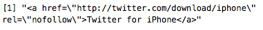

```r
head(tweets)
```

```
## # A tibble: 6 x 4
##   id                 source text                       created
##   <chr>              <chr>  <chr>                      <dttm>
## 1 991995845120753664 iPhone ...despite already having… 2018-05-03 11:00:14
## 2 991994433750142976 iPhone ...very common among cele… 2018-05-03 10:54:38
## 3 991992302267785216 iPhone Mr. Cohen, an attorney, r… 2018-05-03 10:46:09
## 4 991886413686861824 iPhone Our great financial team … 2018-05-03 03:45:24
## 5 991884309400342529 iPhone Ainsley Earnhardt, a trul… 2018-05-03 03:37:02
## 6 991843153953964033 iPhone As everybody is aware, th… 2018-05-03 00:53:30
```

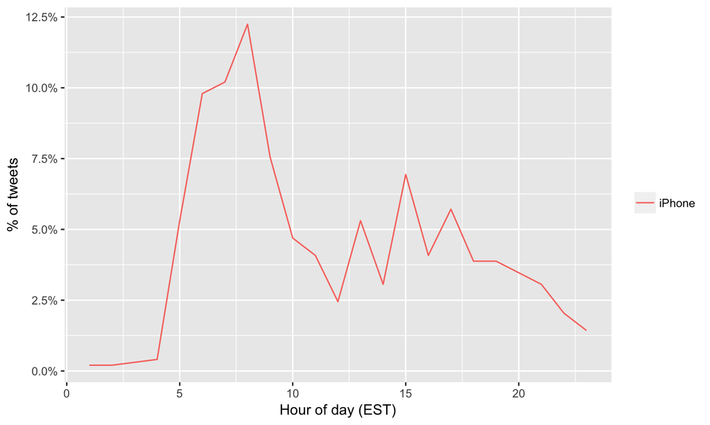

```r
library(lubridate)
library(scales)
library(ggplot2)

tweets %>%
  count(source, hour = hour(with_tz(created, "EST"))) %>%
  mutate(percent = n / sum(n)) %>%
  ggplot(aes(hour, percent, color = source)) +
  geom_line() +
  scale_y_continuous(labels = percent_format()) +
  labs(x = "Hour of day (EST)",
       y = "% of tweets",
       color = "")
```

He also does some sentiment analysis. First he separates the tweets out into words using the unnest_tokens() command from the tidytext library.

```r
library(tidytext)
library(stringr)

reg <- "([^A-Za-z\\d#@']|'(?![A-Za-z\\d#@]))"
tweet_words <- tweets %>%
  filter(!str_detect(text, '^"')) %>%
  mutate(text = str_replace_all(text,
            "https://t.co/[A-Za-z\\d]+|&amp;", "")) %>%
  unnest_tokens(word, text, token = "regex", pattern = reg) %>%
  filter(!word %in% stop_words$word,
         str_detect(word, "[a-z]"))
```

```r
head(tweet_words)
```

```
## # A tibble: 6 x 4
##   id                 source created             word
##   <chr>              <chr>  <dttm>              <chr>
## 1 936555753946705920 iPhone 2017-12-01 11:21:06 republicans
## 2 936555753946705920 iPhone 2017-12-01 11:21:06 senators
## 3 936555753946705920 iPhone 2017-12-01 11:21:06 hard
## 4 936555753946705920 iPhone 2017-12-01 11:21:06 pass
## 5 936555753946705920 iPhone 2017-12-01 11:21:06 biggest
## 6 936555753946705920 iPhone 2017-12-01 11:21:06 tax
```

We can use the sentiment data set from the tidytext library to sort the words by sentiment.

```r
sentiments
```

```
## # A tibble: 27,314 x 4
##    word        sentiment lexicon score
##    <chr>       <chr>     <chr>   <int>
##  1 abacus      trust     nrc        NA
##  2 abandon     fear      nrc        NA
##  3 abandon     negative  nrc        NA
##  4 abandon     sadness   nrc        NA
##  5 abandoned   anger     nrc        NA
##  6 abandoned   fear      nrc        NA
##  7 abandoned   negative  nrc        NA
##  8 abandoned   sadness   nrc        NA
##  9 abandonment anger     nrc        NA
## 10 abandonment fear      nrc        NA
## # ... with 27,304 more rows
```

David Robinson uses the NRC Word-Emotion Association, which sorts words into 10 sentiments: positive, negative, anger, anticipation, disgust, fear, joy, sadness, surprise, and trust.

```r
nrc <- sentiments %>%
  filter(lexicon == "nrc") %>%
  dplyr::select(word, sentiment)

head(nrc)
```

```
## # A tibble: 6 x 2
##   word      sentiment
##   <chr>     <chr>
## 1 abacus    trust
## 2 abandon   fear
## 3 abandon   negative
## 4 abandon   sadness
## 5 abandoned anger
## 6 abandoned fear
```

Then he joins this with the tweet_words data frame to analyze the sentiment of the words in the tweets by source.

```r
library(tidyverse)

sources <- tweet_words %>%
  group_by(source) %>%
  mutate(total_words = n()) %>%
  ungroup() %>%
  distinct(id, source, total_words)
```

```r
by_source_sentiment <- tweet_words %>%
  inner_join(nrc, by = "word") %>%
  count(sentiment, id) %>%
  ungroup() %>%
  complete(sentiment, id, fill = list(n = 0)) %>%
  inner_join(sources) %>%
  group_by(source, sentiment, total_words) %>%
  summarize(words = sum(n)) %>%
  ungroup()
```

```r
head(by_source_sentiment)
```

```
## # A tibble: 6 x 4
##   source sentiment    total_words words
##   <chr>  <chr>              <int> <dbl>
## 1 iPhone anger               3862  184.
## 2 iPhone anticipation        3862  170.
## 3 iPhone disgust             3862  131.
## 4 iPhone fear                3862  211.
## 5 iPhone joy                 3862  167.
## 6 iPhone negative            3862  366.
```

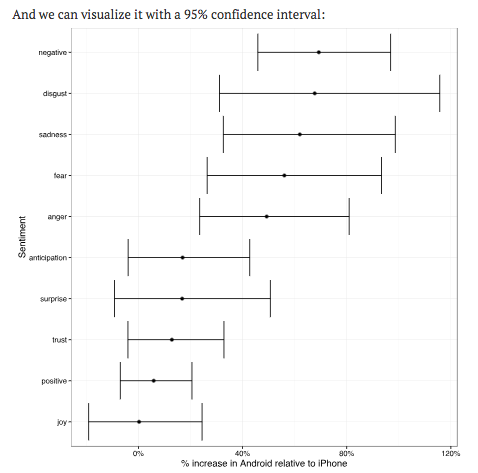